# PoSI Case Study: Telomere Length Analysis

This file demonstrates PoSI on the Telomere Length (TL) analysis by Nersisyan, Nikoghosyan, and Arakelyan (2019). The goal of the analysis is to study the inheritance patterns and associated genetic factors. The data and scripts of their analyses are available on [Github](https://github.com/lilit-nersisyan/gonl_tqtl). Here we focus on the first part of the multiple linear regression (MLR) analysis to understand the TL inheritance patterns. The article concludes from the analysis that TL is a mostly heritable trait, more from mother’s and less from father’s. TL is also age-related and linked to mother’s age at conception. The conclusion is based on regression analysis but with covariate selection that invalidates the classical inference. After our post-selection adjustment to the inference, only the inheritance factors are significant controlling for other covariates.

# 1 MTL data

There are in total 250 family trios in the original data. According to the article, two of the families with missing data for the mother were removed, and two families with discordant age differences at the time of data collection and at conception were also discarded. Hence there are 246 samples left in the `child.df` data. The description of the data is as follows.

| Variable | Description |
| --- | --- |
| GoNL_Sample_ID | id of Genome of the Netherlands (GoNL) project |
| family | family ID |
| member | family member (here are all children, `c`) |
| Sex | sex |
| Age | age |
| MTL | mean telomere length |
| ageC | NA |
| MAC | mother’s age at conception |
| PAC | father’s age at conception |
| mMTL | mother’s mean telomere length |
| fMTL | father’s mean telomere length |
| mAge | mother’s age |
| fAge | father’s age |

```r
# phenotype data for children and parents 246 families
load("gonl_tqtl-master/child.df.RData")

# final model
fit.final <- lm(MTL ~ Age + mMTL + fMTL + MAC + PAC, child.df)

# summary table of the final model
summary(fit.final)
```

```
##
## Call:
## lm(formula = MTL ~ Age + mMTL + fMTL + MAC + PAC, data = child.df)
##
## Residuals:
##     Min      1Q  Median      3Q     Max
## -3242.5  -852.3   -92.9   773.0  4751.8
##
## Coefficients:
##               Estimate Std. Error t value Pr(>|t|)
## (Intercept) 1543.32746  831.59430   1.856  0.06470 .
## Age          -22.89236    9.09633  -2.517  0.01250 *
## mMTL           0.44913    0.06184   7.263 5.27e-12 ***
## fMTL           0.29509    0.06940   4.252 3.04e-05 ***
## MAC           94.23583   31.02572   3.037  0.00265 **
## PAC          -28.76672   28.99659  -0.992  0.32216
## ---
## Signif. codes:  0 '***' 0.001 '**' 0.01 '*' 0.05 '.' 0.1 ' ' 1
##
## Residual standard error: 1254 on 240 degrees of freedom
## Multiple R-squared:  0.4534, Adjusted R-squared:  0.442
## F-statistic: 39.81 on 5 and 240 DF,  p-value: < 2.2e-16
```

```r
# summary table of the final model with sandwich
summ(fit.final, robust = "HC0")
```

| Observations | 246 |
| --- | --- |
| Dependent variable | MTL |
| Type | OLS linear regression |

| F(5,240) | 39.81 |
| --- | --- |
| R² | 0.45 |
| Adj. R² | 0.44 |

|  | Est. | S.E. | t val. | p |
| --- | --- | --- | --- | --- |
| (Intercept) | 1543.33 | 800.23 | 1.93 | 0.05 |
| Age | -22.89 | 7.90 | -2.90 | 0.00 |
| mMTL | 0.45 | 0.06 | 7.25 | 0.00 |
| fMTL | 0.30 | 0.07 | 4.08 | 0.00 |
| MAC | 94.24 | 36.97 | 2.55 | 0.01 |
| PAC | -28.77 | 35.48 | -0.81 | 0.42 |

Standard errors: Robust, type = HC0

```r
# fit.0 <- lm(MTL ~ (Sex + Age + mMTL + fMTL + MAC + PAC)^2, child.df)
x <- model.matrix(MTL ~ (Sex + Age + mMTL + fMTL + MAC + PAC)^2, child.df)
y <- child.df$MTL

# final model
M.final <- 3:7
colnames(x)[M.final]
```

```
## [1] "Age"  "mMTL" "fMTL" "MAC"  "PAC"
```

```r
p <- ncol(x) - 1
nboot <- 1000
```

# 2 PoSI

We provide PoSI adjustment considering selection mentioned in Nersisyan, Nikoghosyan, and Arakelyan (2019).

- Variables: `Sex`, `Age`, `mMTL`, `fMTL`, `MAC`, and `PAC`;
- Interactions: All pairwise interactions.

```r
Hm <- matrix(NA, nrow = p, ncol = nboot)
Hs <- matrix(NA, nrow = p, ncol = nboot)

Hm1 <- matrix(NA, nrow = p, ncol = nboot)
Hs1 <- matrix(NA, nrow = p, ncol = nboot)

Hmp <- array(NA, c(p, nboot, p))
Hsp <- array(NA, c(p, nboot, p))


ks <- 1:p
for(i in seq_along(ks)) {
  k <- ks[i]
  print(k)
  tmp <- max_t_mul_boot_k(x[,-1], y, k,
                          sandwich = T, return_sample = T,
                          Nboot = nboot, intercept = T,
                          individual = 1:p)
  Hs[i, ] <- colMax(tmp$BootSample)
  Hm[i, ] <- colMax(tmp$BootRank)

  Hsp[i,,] <- t(tmp$BootSample1)
  Hmp[i,,] <- t(tmp$BootRank1)

}

# PoSI constant with prepivot
K_norm <- get_T(x[,-1], y, M.final, NULL, Hm, maxk = p, Nboot = nboot, intercept = T, adjust = T)
# PoSI1 constant with prepivot
K_norm1 <- sapply(M.final, function(i) get_T(x[,-1], y, M.final, NULL, Hmp[,,i], maxk = p, Nboot = nboot, intercept = T, adjust = T))

# adjusted p
se <- sqrt(diag(vcovHC(fit.final, "HC0")))[-1]
t.s <- coef(fit.final)[-1]/se
pval_norm <- get_p(t.s, x[,-1], y, M.final, NULL, Hm, maxk = p, Nboot = nboot, intercept = T, adjust = T)
pval_norm1 <- sapply(1:length(M.final), function(i) get_p(t.s[i], x[,-1], y, M.final, NULL, Hmp[,,M.final[i]], maxk = p, Nboot = nboot, intercept = T, adjust = T))

saveRDS(list(K_norm = K_norm, K_norm1 = K_norm1,
             pval_norm = pval_norm, pval_norm1 = pval_norm1),
        "MTL_PoSI.RDS")
```

# 3 Report

After PoSI or PoSI1 adjustment, `AGE` and `MAC` change from significant at 0.05 level to insignificant. The adjustment changes the conclusion of the study to TL is a heritable trait only. The heritable nature of telomeres, as the authors claim, echoes prior studies. Age and parents’ ages at conception, however, are not significant factors. The authors claim there is a lack of evidence on effect of MAC in previous studies and their MLR analysis (with covariate selection) confirms the association of MAC with offspring MTL, suggesting that further investigation. Nevertheless, after PoSI adjustment for selection, MAC is not significant anymore.

| Variable | Unadjusted | Adjusted |
| --- | --- | --- |
| $\color{red}{\text{Age}}$ | ✓ | ✗ |
| mMTL | ✓ | ✓ |
| fMTL | ✓ | ✓ |
| $\color{red}{\text{MAC}}$ | ✓ | ✗ |
| PAC | ✗ | ✗ |

```r
ret <- readRDS("MTL_PoSI.RDS")
K_norm <- ret$K_norm; K_norm1 <- ret$K_norm1
pval_norm <- ret$pval_norm; pval_norm1 <- ret$pval_norm1

fit.final <- lm(MTL ~ Age + mMTL + fMTL + MAC + PAC, child.df)

se <- sqrt(diag(vcovHC(fit.final, "HC0")))[-1]
fit.final.ci <- summ(fit.final, confint = T)$coeftable[-1,]

ret.p <-
  data.table(var = factor(colnames(x)[M.final],
                          levels = colnames(x)[M.final]),
             pval_t = summ(fit.final)$coeftable[-1, 4],
             pval_adjust = pval_norm,
             pval_adjust1 = pval_norm1)

ret.ci <-
  data.table(var = factor(rep(colnames(x)[M.final], 3),
                          levels = colnames(x)[M.final]),
             method = factor(rep(c("t", "adjust", "adjust1"),
                                 each = length(M.final)),
                             levels = c("t", "adjust", "adjust1")),
             lower = c(fit.final.ci[,2],
                       fit.final$coefficients[-1] - K_norm * se,
                       fit.final$coefficients[-1] - K_norm1 * se
             ),
             upper = c(fit.final.ci[,3],
                       fit.final$coefficients[-1] + K_norm * se,
                       fit.final$coefficients[-1] + K_norm1 * se
             )
  )

# xtable(ret.ci)
ret.ci.wide <- dcast(ret.ci, var ~ method, value.var = c("lower", "upper"))
name.order <- 1
for(method in c("t", "adjust", "adjust1")) {
  col.idx <- grep(paste0("^", method, "$"),
                  sapply(strsplit(names(ret.ci.wide), "_"), tail, 1))
  ret.ci.wide[, eval(method)] <-
    Reduce("*",
           ret.ci.wide[, col.idx,
                       with=F]) > 0
  name.order <- c(name.order, col.idx, ncol(ret.ci.wide))
}
ret.ci.wide <- ret.ci.wide[,name.order,with=F]

ret.ci.wide <- dcast(ret.ci, var ~ method, value.var = c("lower", "upper"))
name.order <- 1
for(method in c("t","adjust", "adjust1")) {
  col.idx <- grep(paste0("^", method, "$"),
                  sapply(strsplit(names(ret.ci.wide), "_"), tail, 1))
  ret.ci.wide[, eval(method)] <-
    Reduce("*",
           ret.ci.wide[, col.idx,
                       with=F]) > 0
  # name.order <- c(name.order, col.idx, ncol(ret.ci.wide))
}
ret.ci.wide$K_t <- 1.96
ret.ci.wide$K_adjust <- K_norm
ret.ci.wide$K_adjust1 <- K_norm1
ret.ci.wide <- merge(ret.ci.wide, ret.p, by = "var")

for(method in c("t","adjust", "adjust1")) {
  col.idx <- grep(paste0("^", method, "$"),
                  sapply(strsplit(names(ret.ci.wide), "_"), tail, 1))
  name.order <- c(name.order, col.idx)
}
ret.ci.wide <- ret.ci.wide[,name.order,with=F]

changed.idx <- as.matrix(ret.ci.wide[, .SD, .SDcols = c("t", "adjust1")])
changed.idx[changed.idx] <- 1; changed.idx[!changed.idx] <- -1
changed.idx <- which(rowProds(changed.idx) != 1)
```

```r
# the unadjusted with sandwich
kable(ret.ci.wide[, 1:6]) %>%
  kable_styling("striped", full_width = F) %>%
  row_spec(changed.idx, bold = T, color = "white", background = "#D7261E")
```

| var | lower_t | upper_t | t | K_t | pval_t |
| --- | --- | --- | --- | --- | --- |
| Age | -40.8111970 | -4.9735147 | TRUE | 1.96 | 0.0125005 |
| mMTL | 0.3273123 | 0.5709566 | TRUE | 1.96 | 0.0000000 |
| fMTL | 0.1583824 | 0.4318060 | TRUE | 1.96 | 0.0000304 |
| MAC | 33.1183286 | 155.3533262 | TRUE | 1.96 | 0.0026503 |
| PAC | -85.8870371 | 28.3535898 | FALSE | 1.96 | 0.3221612 |

## 3.2 Simultaneous Inference with selection and misspecification adjustment

```r
# PoSI adjusted
kable(ret.ci.wide[, c(1, 7:11)]) %>%
  kable_styling("striped", full_width = F) %>%
  row_spec(changed.idx, bold = T, color = "white", background = "#D7261E")
```

| var | lower_adjust | upper_adjust | adjust | K_adjust | pval_adjust |
| --- | --- | --- | --- | --- | --- |
| Age | -52.8342403 | 7.0495286 | FALSE | 3.800056 | 0.97003 |
| mMTL | 0.2141519 | 0.6841170 | TRUE | 3.800056 | 0.00000 |
| fMTL | 0.0207981 | 0.5693903 | TRUE | 3.800056 | 0.00000 |
| MAC | -45.9665261 | 234.4381810 | FALSE | 3.800056 | 1.00000 |
| PAC | -163.3127546 | 105.7793073 | FALSE | 3.800056 | 1.00000 |

## 3.3 Marginal Inference with selection and misspecification adjustment

```r
# PoSI1 adjusted
kable(ret.ci.wide[, c(1, 12:16)]) %>%
  kable_styling("striped", full_width = F) %>%
  row_spec(changed.idx, bold = T, color = "white", background = "#D7261E")
```

| var | lower_adjust1 | upper_adjust1 | adjust1 | K_adjust1 | pval_adjust1 |
| --- | --- | --- | --- | --- | --- |
| Age | -48.0568020 | 2.2720903 | FALSE | 3.193730 | 0.0779221 |
| mMTL | 0.2605776 | 0.6376913 | TRUE | 3.049276 | 0.0000000 |
| fMTL | 0.0645640 | 0.5256245 | TRUE | 3.193730 | 0.0000000 |
| MAC | -23.3074317 | 211.7790866 | FALSE | 3.185902 | 0.2287712 |
| PAC | -141.5678186 | 84.0343712 | FALSE | 3.185902 | 1.0000000 |

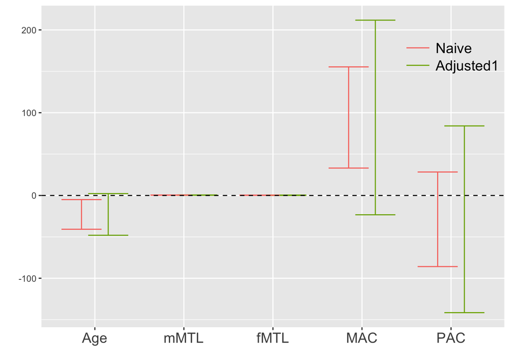

```r
ret.ci %>%
  filter(method %in% c("t", "adjust1")) %>%
  ggplot(aes(x = var, col = method)) +
  geom_errorbar(aes(ymin = lower, ymax = upper), position=position_dodge(0.6)) +
  geom_hline(yintercept = 0, linetype = "dashed") +
  scale_color_manual(values = hue_pal()(4),
                     labels = c("Naive", "Adjusted1")) +
  xlab("") +
  ylab("") +
  theme(legend.key=element_blank(),
        legend.key.width = unit(1,"cm"),
        legend.background=element_blank(),
        legend.position = c(1, 0.85),
        legend.direction = "vertical",
        legend.justification="right",
        legend.spacing.x = unit(0.05, 'in'),
        legend.title = element_blank(),
        legend.text = element_text(size = 14),
        axis.text.x = element_text(size = 14))
```

Nersisyan, Lilit, Maria Nikoghosyan, and Arsen Arakelyan. 2019. “WGS-Based Telomere Length Analysis in Dutch Family Trios Implicates Stronger Maternal Inheritance and a Role for Rrm1 Gene.” *Scientific Reports* 9 (1): 1–9.